# Risk Factor Analysis

## Outcome Variable

**Outcome Variable:** wast_rec90d

## Predictor Variables

**Intervention Variable:** mbmi

**Adjustment Set:**

unadjusted

## Stratifying Variables

The analysis was stratified on these variable(s):

- agecat
- studyid
- country

## Data Summary

| agecat | studyid | country | mbmi | wast_rec90d | n_cell | n |
| --- | --- | --- | --- | --- | --- | --- |
| 0-24 months | ki0047075b-MAL-ED | BANGLADESH | Normal weight | 0 | 30 | 122 |
| 0-24 months | ki0047075b-MAL-ED | BANGLADESH | Normal weight | 1 | 63 | 122 |
| 0-24 months | ki0047075b-MAL-ED | BANGLADESH | Underweight | 0 | 14 | 122 |
| 0-24 months | ki0047075b-MAL-ED | BANGLADESH | Underweight | 1 | 15 | 122 |
| 0-24 months | ki0047075b-MAL-ED | BRAZIL | Normal weight | 0 | 6 | 23 |
| 0-24 months | ki0047075b-MAL-ED | BRAZIL | Normal weight | 1 | 15 | 23 |
| 0-24 months | ki0047075b-MAL-ED | BRAZIL | Underweight | 0 | 0 | 23 |
| 0-24 months | ki0047075b-MAL-ED | BRAZIL | Underweight | 1 | 2 | 23 |
| 0-24 months | ki0047075b-MAL-ED | INDIA | Normal weight | 0 | 48 | 175 |
| 0-24 months | ki0047075b-MAL-ED | INDIA | Normal weight | 1 | 80 | 175 |
| 0-24 months | ki0047075b-MAL-ED | INDIA | Underweight | 0 | 22 | 175 |
| 0-24 months | ki0047075b-MAL-ED | INDIA | Underweight | 1 | 25 | 175 |
| 0-24 months | ki0047075b-MAL-ED | NEPAL | Normal weight | 0 | 20 | 93 |
| 0-24 months | ki0047075b-MAL-ED | NEPAL | Normal weight | 1 | 73 | 93 |
| 0-24 months | ki0047075b-MAL-ED | NEPAL | Underweight | 0 | 0 | 93 |
| 0-24 months | ki0047075b-MAL-ED | NEPAL | Underweight | 1 | 0 | 93 |
| 0-24 months | ki0047075b-MAL-ED | PERU | Normal weight | 0 | 5 | 34 |
| 0-24 months | ki0047075b-MAL-ED | PERU | Normal weight | 1 | 25 | 34 |
| 0-24 months | ki0047075b-MAL-ED | PERU | Underweight | 0 | 1 | 34 |
| 0-24 months | ki0047075b-MAL-ED | PERU | Underweight | 1 | 3 | 34 |
| 0-24 months | ki0047075b-MAL-ED | SOUTH AFRICA | Normal weight | 0 | 13 | 77 |
| 0-24 months | ki0047075b-MAL-ED | SOUTH AFRICA | Normal weight | 1 | 64 | 77 |
| 0-24 months | ki0047075b-MAL-ED | SOUTH AFRICA | Underweight | 0 | 0 | 77 |
| 0-24 months | ki0047075b-MAL-ED | SOUTH AFRICA | Underweight | 1 | 0 | 77 |
| 0-24 months | ki0047075b-MAL-ED | TANZANIA, UNITED REPUBLIC OF | Normal weight | 0 | 7 | 45 |
| 0-24 months | ki0047075b-MAL-ED | TANZANIA, UNITED REPUBLIC OF | Normal weight | 1 | 34 | 45 |
| 0-24 months | ki0047075b-MAL-ED | TANZANIA, UNITED REPUBLIC OF | Underweight | 0 | 1 | 45 |
| 0-24 months | ki0047075b-MAL-ED | TANZANIA, UNITED REPUBLIC OF | Underweight | 1 | 3 | 45 |
| 0-24 months | ki1000304b-SAS-CompFeed | INDIA | Normal weight | 0 | 86 | 207 |
| 0-24 months | ki1000304b-SAS-CompFeed | INDIA | Normal weight | 1 | 39 | 207 |

[output cut: 158 more lines]

The following strata were considered:

- agecat: 0-24 months, studyid: ki0047075b-MAL-ED, country: BANGLADESH
- agecat: 0-24 months, studyid: ki0047075b-MAL-ED, country: BRAZIL
- agecat: 0-24 months, studyid: ki0047075b-MAL-ED, country: INDIA
- agecat: 0-24 months, studyid: ki0047075b-MAL-ED, country: NEPAL
- agecat: 0-24 months, studyid: ki0047075b-MAL-ED, country: PERU
- agecat: 0-24 months, studyid: ki0047075b-MAL-ED, country: SOUTH AFRICA
- agecat: 0-24 months, studyid: ki0047075b-MAL-ED, country: TANZANIA, UNITED REPUBLIC OF
- agecat: 0-24 months, studyid: ki1000304b-SAS-CompFeed, country: INDIA
- agecat: 0-24 months, studyid: ki1017093-NIH-Birth, country: BANGLADESH
- agecat: 0-24 months, studyid: ki1017093b-PROVIDE, country: BANGLADESH
- agecat: 0-24 months, studyid: ki1017093c-NIH-Crypto, country: BANGLADESH
- agecat: 0-24 months, studyid: ki1066203-TanzaniaChild2, country: TANZANIA, UNITED REPUBLIC OF
- agecat: 0-24 months, studyid: ki1112895-iLiNS-Zinc, country: BURKINA FASO
- agecat: 0-24 months, studyid: ki1119695-PROBIT, country: BELARUS
- agecat: 0-24 months, studyid: ki1126311-ZVITAMBO, country: ZIMBABWE
- agecat: 0-24 months, studyid: ki1148112-LCNI-5, country: MALAWI
- agecat: 0-6 months, studyid: ki0047075b-MAL-ED, country: BANGLADESH
- agecat: 0-6 months, studyid: ki0047075b-MAL-ED, country: BRAZIL
- agecat: 0-6 months, studyid: ki0047075b-MAL-ED, country: INDIA
- agecat: 0-6 months, studyid: ki0047075b-MAL-ED, country: NEPAL
- agecat: 0-6 months, studyid: ki0047075b-MAL-ED, country: PERU
- agecat: 0-6 months, studyid: ki0047075b-MAL-ED, country: SOUTH AFRICA
- agecat: 0-6 months, studyid: ki0047075b-MAL-ED, country: TANZANIA, UNITED REPUBLIC OF
- agecat: 0-6 months, studyid: ki1000304b-SAS-CompFeed, country: INDIA
- agecat: 0-6 months, studyid: ki1017093-NIH-Birth, country: BANGLADESH
- agecat: 0-6 months, studyid: ki1017093b-PROVIDE, country: BANGLADESH
- agecat: 0-6 months, studyid: ki1017093c-NIH-Crypto, country: BANGLADESH
- agecat: 0-6 months, studyid: ki1066203-TanzaniaChild2, country: TANZANIA, UNITED REPUBLIC OF
- agecat: 0-6 months, studyid: ki1119695-PROBIT, country: BELARUS
- agecat: 0-6 months, studyid: ki1126311-ZVITAMBO, country: ZIMBABWE
- agecat: 0-6 months, studyid: ki1148112-LCNI-5, country: MALAWI
- agecat: 6-24 months, studyid: ki0047075b-MAL-ED, country: BANGLADESH
- agecat: 6-24 months, studyid: ki0047075b-MAL-ED, country: BRAZIL
- agecat: 6-24 months, studyid: ki0047075b-MAL-ED, country: INDIA
- agecat: 6-24 months, studyid: ki0047075b-MAL-ED, country: NEPAL
- agecat: 6-24 months, studyid: ki0047075b-MAL-ED, country: PERU
- agecat: 6-24 months, studyid: ki0047075b-MAL-ED, country: SOUTH AFRICA
- agecat: 6-24 months, studyid: ki0047075b-MAL-ED, country: TANZANIA, UNITED REPUBLIC OF
- agecat: 6-24 months, studyid: ki1000304b-SAS-CompFeed, country: INDIA
- agecat: 6-24 months, studyid: ki1017093-NIH-Birth, country: BANGLADESH
- agecat: 6-24 months, studyid: ki1017093b-PROVIDE, country: BANGLADESH
- agecat: 6-24 months, studyid: ki1017093c-NIH-Crypto, country: BANGLADESH
- agecat: 6-24 months, studyid: ki1066203-TanzaniaChild2, country: TANZANIA, UNITED REPUBLIC OF
- agecat: 6-24 months, studyid: ki1112895-iLiNS-Zinc, country: BURKINA FASO
- agecat: 6-24 months, studyid: ki1119695-PROBIT, country: BELARUS
- agecat: 6-24 months, studyid: ki1126311-ZVITAMBO, country: ZIMBABWE
- agecat: 6-24 months, studyid: ki1148112-LCNI-5, country: MALAWI

### Dropped Strata

Some strata were dropped due to rare outcomes:

- agecat: 0-24 months, studyid: ki0047075b-MAL-ED, country: BRAZIL
- agecat: 0-24 months, studyid: ki0047075b-MAL-ED, country: NEPAL
- agecat: 0-24 months, studyid: ki0047075b-MAL-ED, country: PERU
- agecat: 0-24 months, studyid: ki0047075b-MAL-ED, country: SOUTH AFRICA
- agecat: 0-24 months, studyid: ki0047075b-MAL-ED, country: TANZANIA, UNITED REPUBLIC OF
- agecat: 0-24 months, studyid: ki1112895-iLiNS-Zinc, country: BURKINA FASO
- agecat: 0-6 months, studyid: ki0047075b-MAL-ED, country: BRAZIL
- agecat: 0-6 months, studyid: ki0047075b-MAL-ED, country: NEPAL
- agecat: 0-6 months, studyid: ki0047075b-MAL-ED, country: PERU
- agecat: 0-6 months, studyid: ki0047075b-MAL-ED, country: SOUTH AFRICA
- agecat: 0-6 months, studyid: ki0047075b-MAL-ED, country: TANZANIA, UNITED REPUBLIC OF
- agecat: 0-6 months, studyid: ki1017093c-NIH-Crypto, country: BANGLADESH
- agecat: 0-6 months, studyid: ki1066203-TanzaniaChild2, country: TANZANIA, UNITED REPUBLIC OF
- agecat: 0-6 months, studyid: ki1148112-LCNI-5, country: MALAWI
- agecat: 6-24 months, studyid: ki0047075b-MAL-ED, country: BRAZIL
- agecat: 6-24 months, studyid: ki0047075b-MAL-ED, country: NEPAL
- agecat: 6-24 months, studyid: ki0047075b-MAL-ED, country: PERU
- agecat: 6-24 months, studyid: ki0047075b-MAL-ED, country: SOUTH AFRICA
- agecat: 6-24 months, studyid: ki0047075b-MAL-ED, country: TANZANIA, UNITED REPUBLIC OF
- agecat: 6-24 months, studyid: ki1017093c-NIH-Crypto, country: BANGLADESH
- agecat: 6-24 months, studyid: ki1066203-TanzaniaChild2, country: TANZANIA, UNITED REPUBLIC OF
- agecat: 6-24 months, studyid: ki1112895-iLiNS-Zinc, country: BURKINA FASO
- agecat: 6-24 months, studyid: ki1119695-PROBIT, country: BELARUS

## Methods Detail

We’re interested in the causal parameters $E[Y_a]$ for all values of $a \in \mathcal{A}$. These parameters represent the mean outcome if, possibly contrary to fact, we intervened to set all units to have $A=a$. Under the randomization and positivity assumptions, these are identified by the statistical parameters $\psi_a=E_W[E_{Y|A,W}(Y|A=a,W)]$. In addition, we’re interested in the mean of $Y$, $E[Y]$ under no intervention (the observed mean). We will estimate these parameters by using SuperLearner to fit the relevant likelihood factors – $E_{Y|A,W}(Y|A=a,W)$ and $p(A=a|W)$, and then updating our likelihood fit using a joint TMLE.

For unadjusted analyses ($W=\{\}$), initial likelihoods were estimated using Lrnr_glm to estimate the simple $E(Y|A)$ and Lrnr_mean to estimate $p(A)$. For adjusted analyses, a small library containing Lrnr_glmnet, Lrnr_xgboost, and Lrnr_mean was used.

Having estimated these parameters, we will then use the delta method to estimate relative risks and attributable risks relative to a prespecified baseline level of $A$.

# Results Detail

## Results Plots

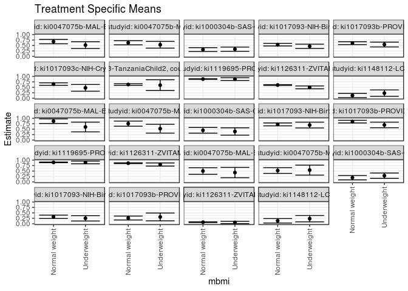

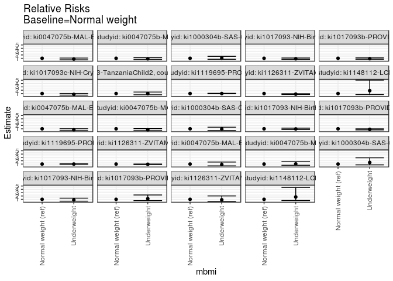

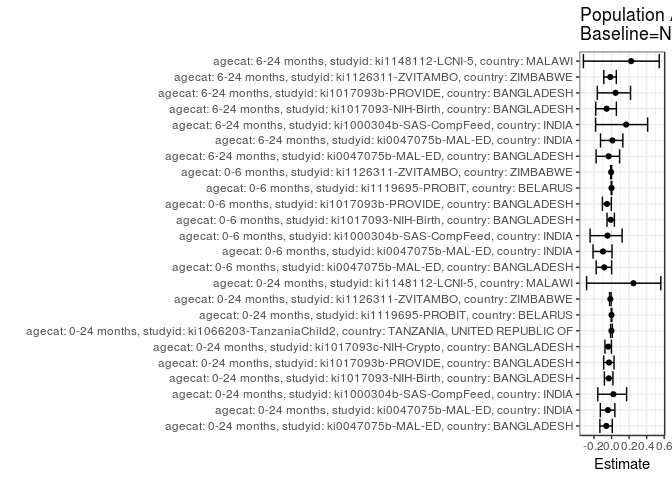

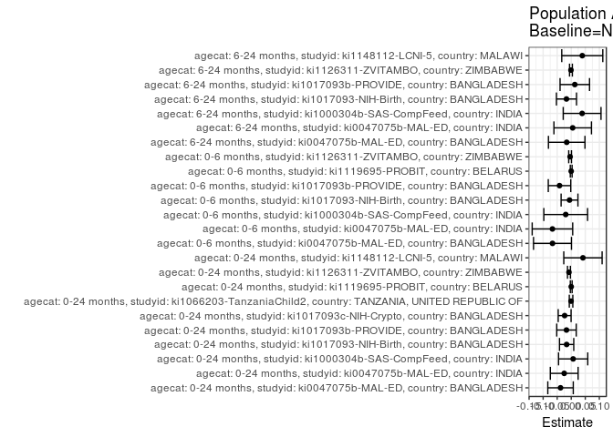

## Results Table

### Parameter: TSM

| agecat | studyid | country | intervention_level | baseline_level | estimate | ci_lower | ci_upper |
| --- | --- | --- | --- | --- | --- | --- | --- |
| 0-24 months | ki0047075b-MAL-ED | BANGLADESH | Normal weight | NA | 0.6774194 | 0.5768557 | 0.7779831 |
| 0-24 months | ki0047075b-MAL-ED | BANGLADESH | Underweight | NA | 0.5172414 | 0.3618476 | 0.6726352 |
| 0-24 months | ki0047075b-MAL-ED | INDIA | Normal weight | NA | 0.6250000 | 0.5312352 | 0.7187648 |
| 0-24 months | ki0047075b-MAL-ED | INDIA | Underweight | NA | 0.5319149 | 0.3779503 | 0.6858794 |
| 0-24 months | ki1000304b-SAS-CompFeed | INDIA | Normal weight | NA | 0.3120000 | 0.2241434 | 0.3998566 |
| 0-24 months | ki1000304b-SAS-CompFeed | INDIA | Underweight | NA | 0.3292683 | 0.2317022 | 0.4268344 |
| 0-24 months | ki1017093-NIH-Birth | BANGLADESH | Normal weight | NA | 0.5365854 | 0.4780574 | 0.5951134 |
| 0-24 months | ki1017093-NIH-Birth | BANGLADESH | Underweight | NA | 0.4623656 | 0.3638762 | 0.5608549 |
| 0-24 months | ki1017093b-PROVIDE | BANGLADESH | Normal weight | NA | 0.6063348 | 0.5400676 | 0.6726021 |
| 0-24 months | ki1017093b-PROVIDE | BANGLADESH | Underweight | NA | 0.5432099 | 0.4323617 | 0.6540581 |
| 0-24 months | ki1017093c-NIH-Crypto | BANGLADESH | Normal weight | NA | 0.6492537 | 0.5923744 | 0.7061331 |
| 0-24 months | ki1017093c-NIH-Crypto | BANGLADESH | Underweight | NA | 0.4761905 | 0.3222340 | 0.6301469 |
| 0-24 months | ki1066203-TanzaniaChild2 | TANZANIA, UNITED REPUBLIC OF | Normal weight | NA | 0.6288210 | 0.5904220 | 0.6672199 |
| 0-24 months | ki1066203-TanzaniaChild2 | TANZANIA, UNITED REPUBLIC OF | Underweight | NA | 0.6000000 | 0.3523180 | 0.8476820 |
| 0-24 months | ki1119695-PROBIT | BELARUS | Normal weight | NA | 0.8782189 | 0.8634070 | 0.8930308 |
| 0-24 months | ki1119695-PROBIT | BELARUS | Underweight | NA | 0.8775510 | 0.8156053 | 0.9394968 |
| 0-24 months | ki1126311-ZVITAMBO | ZIMBABWE | Normal weight | NA | 0.6048682 | 0.5854705 | 0.6242658 |
| 0-24 months | ki1126311-ZVITAMBO | ZIMBABWE | Underweight | NA | 0.4975124 | 0.4322744 | 0.5627505 |
| 0-24 months | ki1148112-LCNI-5 | MALAWI | Normal weight | NA | 0.1250000 | 0.0290888 | 0.2209112 |
| 0-24 months | ki1148112-LCNI-5 | MALAWI | Underweight | NA | 0.2333333 | 0.0868920 | 0.3797747 |
| 0-6 months | ki0047075b-MAL-ED | BANGLADESH | Normal weight | NA | 0.8666667 | 0.7613735 | 0.9719599 |
| 0-6 months | ki0047075b-MAL-ED | BANGLADESH | Underweight | NA | 0.6000000 | 0.3771424 | 0.8228576 |
| 0-6 months | ki0047075b-MAL-ED | INDIA | Normal weight | NA | 0.7543860 | 0.6366726 | 0.8720993 |
| 0-6 months | ki0047075b-MAL-ED | INDIA | Underweight | NA | 0.5217391 | 0.3196842 | 0.7237941 |
| 0-6 months | ki1000304b-SAS-CompFeed | INDIA | Normal weight | NA | 0.4482759 | 0.3185144 | 0.5780373 |
| 0-6 months | ki1000304b-SAS-CompFeed | INDIA | Underweight | NA | 0.3939394 | 0.2247795 | 0.5630993 |
| 0-6 months | ki1017093-NIH-Birth | BANGLADESH | Normal weight | NA | 0.7191011 | 0.6526289 | 0.7855734 |
| 0-6 months | ki1017093-NIH-Birth | BANGLADESH | Underweight | NA | 0.6888889 | 0.5565481 | 0.8212297 |
| 0-6 months | ki1017093b-PROVIDE | BANGLADESH | Normal weight | NA | 0.8461538 | 0.7852611 | 0.9070465 |
| 0-6 months | ki1017093b-PROVIDE | BANGLADESH | Underweight | NA | 0.6938776 | 0.5657047 | 0.8220504 |
| 0-6 months | ki1119695-PROBIT | BELARUS | Normal weight | NA | 0.8964187 | 0.8822641 | 0.9105734 |
| 0-6 months | ki1119695-PROBIT | BELARUS | Underweight | NA | 0.8936170 | 0.8306439 | 0.9565901 |
| 0-6 months | ki1126311-ZVITAMBO | ZIMBABWE | Normal weight | NA | 0.8586826 | 0.8420281 | 0.8753372 |
| 0-6 months | ki1126311-ZVITAMBO | ZIMBABWE | Underweight | NA | 0.7983193 | 0.7270040 | 0.8696346 |
| 6-24 months | ki0047075b-MAL-ED | BANGLADESH | Normal weight | NA | 0.5000000 | 0.3485042 | 0.6514958 |
| 6-24 months | ki0047075b-MAL-ED | BANGLADESH | Underweight | NA | 0.4285714 | 0.1923941 | 0.6647488 |
| 6-24 months | ki0047075b-MAL-ED | INDIA | Normal weight | NA | 0.5211268 | 0.3887216 | 0.6535319 |
| 6-24 months | ki0047075b-MAL-ED | INDIA | Underweight | NA | 0.5416667 | 0.3131455 | 0.7701879 |
| 6-24 months | ki1000304b-SAS-CompFeed | INDIA | Normal weight | NA | 0.1940299 | 0.0943300 | 0.2937297 |
| 6-24 months | ki1000304b-SAS-CompFeed | INDIA | Underweight | NA | 0.2857143 | 0.1632185 | 0.4082101 |
| 6-24 months | ki1017093-NIH-Birth | BANGLADESH | Normal weight | NA | 0.3200000 | 0.2435094 | 0.3964906 |
| 6-24 months | ki1017093-NIH-Birth | BANGLADESH | Underweight | NA | 0.2500000 | 0.1270597 | 0.3729403 |
| 6-24 months | ki1017093b-PROVIDE | BANGLADESH | Normal weight | NA | 0.2637363 | 0.1740755 | 0.3533970 |
| 6-24 months | ki1017093b-PROVIDE | BANGLADESH | Underweight | NA | 0.3125000 | 0.1324872 | 0.4925128 |
| 6-24 months | ki1126311-ZVITAMBO | ZIMBABWE | Normal weight | NA | 0.0716981 | 0.0538446 | 0.0895517 |
| 6-24 months | ki1126311-ZVITAMBO | ZIMBABWE | Underweight | NA | 0.0609756 | 0.0103160 | 0.1116352 |
| 6-24 months | ki1148112-LCNI-5 | MALAWI | Normal weight | NA | 0.1363636 | 0.0329768 | 0.2397505 |
| 6-24 months | ki1148112-LCNI-5 | MALAWI | Underweight | NA | 0.2333333 | 0.0877343 | 0.3789324 |

### Parameter: E(Y)

| agecat | studyid | country | intervention_level | baseline_level | estimate | ci_lower | ci_upper |
| --- | --- | --- | --- | --- | --- | --- | --- |
| 0-24 months | ki0047075b-MAL-ED | BANGLADESH | NA | NA | 0.6393443 | 0.5530901 | 0.7255985 |
| 0-24 months | ki0047075b-MAL-ED | INDIA | NA | NA | 0.6000000 | 0.5192868 | 0.6807132 |
| 0-24 months | ki1000304b-SAS-CompFeed | INDIA | NA | NA | 0.3188406 | 0.2532736 | 0.3844075 |
| 0-24 months | ki1017093-NIH-Birth | BANGLADESH | NA | NA | 0.5201900 | 0.4695846 | 0.5707955 |
| 0-24 months | ki1017093b-PROVIDE | BANGLADESH | NA | NA | 0.5894040 | 0.5323948 | 0.6464131 |
| 0-24 months | ki1017093c-NIH-Crypto | BANGLADESH | NA | NA | 0.6258065 | 0.5718723 | 0.6797406 |
| 0-24 months | ki1066203-TanzaniaChild2 | TANZANIA, UNITED REPUBLIC OF | NA | NA | 0.6282051 | 0.5902579 | 0.6661523 |
| 0-24 months | ki1119695-PROBIT | BELARUS | NA | NA | 0.8781855 | 0.8637774 | 0.8925937 |
| 0-24 months | ki1126311-ZVITAMBO | ZIMBABWE | NA | NA | 0.5967742 | 0.5781484 | 0.6154000 |
| 0-24 months | ki1148112-LCNI-5 | MALAWI | NA | NA | 0.1666667 | 0.0842830 | 0.2490503 |
| 0-6 months | ki0047075b-MAL-ED | BANGLADESH | NA | NA | 0.8000000 | 0.6995926 | 0.9004074 |
| 0-6 months | ki0047075b-MAL-ED | INDIA | NA | NA | 0.6875000 | 0.5825226 | 0.7924774 |
| 0-6 months | ki1000304b-SAS-CompFeed | INDIA | NA | NA | 0.4285714 | 0.3254972 | 0.5316457 |
| 0-6 months | ki1017093-NIH-Birth | BANGLADESH | NA | NA | 0.7130045 | 0.6535890 | 0.7724200 |
| 0-6 months | ki1017093b-PROVIDE | BANGLADESH | NA | NA | 0.8044693 | 0.7471161 | 0.8618224 |
| 0-6 months | ki1119695-PROBIT | BELARUS | NA | NA | 0.8962808 | 0.8824705 | 0.9100911 |
| 0-6 months | ki1126311-ZVITAMBO | ZIMBABWE | NA | NA | 0.8546674 | 0.8383989 | 0.8709359 |
| 6-24 months | ki0047075b-MAL-ED | BANGLADESH | NA | NA | 0.4838710 | 0.3544124 | 0.6133295 |
| 6-24 months | ki0047075b-MAL-ED | INDIA | NA | NA | 0.5263158 | 0.4116286 | 0.6410029 |
| 6-24 months | ki1000304b-SAS-CompFeed | INDIA | NA | NA | 0.2327586 | 0.1548379 | 0.3106793 |
| 6-24 months | ki1017093-NIH-Birth | BANGLADESH | NA | NA | 0.3030303 | 0.2377927 | 0.3682679 |
| 6-24 months | ki1017093b-PROVIDE | BANGLADESH | NA | NA | 0.2764228 | 0.1950773 | 0.3577682 |
| 6-24 months | ki1126311-ZVITAMBO | ZIMBABWE | NA | NA | 0.0706956 | 0.0538314 | 0.0875597 |
| 6-24 months | ki1148112-LCNI-5 | MALAWI | NA | NA | 0.1756757 | 0.0897916 | 0.2615597 |

### Parameter: RR

| agecat | studyid | country | intervention_level | baseline_level | estimate | ci_lower | ci_upper |
| --- | --- | --- | --- | --- | --- | --- | --- |
| 0-24 months | ki0047075b-MAL-ED | BANGLADESH | Normal weight | Normal weight | 1.0000000 | 1.0000000 | 1.0000000 |
| 0-24 months | ki0047075b-MAL-ED | BANGLADESH | Underweight | Normal weight | 0.7635468 | 0.5460098 | 1.0677533 |
| 0-24 months | ki0047075b-MAL-ED | INDIA | Normal weight | Normal weight | 1.0000000 | 1.0000000 | 1.0000000 |
| 0-24 months | ki0047075b-MAL-ED | INDIA | Underweight | Normal weight | 0.8510638 | 0.6142955 | 1.1790900 |
| 0-24 months | ki1000304b-SAS-CompFeed | INDIA | Normal weight | Normal weight | 1.0000000 | 1.0000000 | 1.0000000 |
| 0-24 months | ki1000304b-SAS-CompFeed | INDIA | Underweight | Normal weight | 1.0553471 | 0.7011570 | 1.5884565 |
| 0-24 months | ki1017093-NIH-Birth | BANGLADESH | Normal weight | Normal weight | 1.0000000 | 1.0000000 | 1.0000000 |
| 0-24 months | ki1017093-NIH-Birth | BANGLADESH | Underweight | Normal weight | 0.8616813 | 0.6782339 | 1.0947472 |
| 0-24 months | ki1017093b-PROVIDE | BANGLADESH | Normal weight | Normal weight | 1.0000000 | 1.0000000 | 1.0000000 |
| 0-24 months | ki1017093b-PROVIDE | BANGLADESH | Underweight | Normal weight | 0.8958909 | 0.7106751 | 1.1293776 |
| 0-24 months | ki1017093c-NIH-Crypto | BANGLADESH | Normal weight | Normal weight | 1.0000000 | 1.0000000 | 1.0000000 |
| 0-24 months | ki1017093c-NIH-Crypto | BANGLADESH | Underweight | Normal weight | 0.7334428 | 0.5245827 | 1.0254596 |
| 0-24 months | ki1066203-TanzaniaChild2 | TANZANIA, UNITED REPUBLIC OF | Normal weight | Normal weight | 1.0000000 | 1.0000000 | 1.0000000 |
| 0-24 months | ki1066203-TanzaniaChild2 | TANZANIA, UNITED REPUBLIC OF | Underweight | Normal weight | 0.9541667 | 0.6286319 | 1.4482784 |
| 0-24 months | ki1119695-PROBIT | BELARUS | Normal weight | Normal weight | 1.0000000 | 1.0000000 | 1.0000000 |
| 0-24 months | ki1119695-PROBIT | BELARUS | Underweight | Normal weight | 0.9992395 | 0.9292872 | 1.0744575 |
| 0-24 months | ki1126311-ZVITAMBO | ZIMBABWE | Normal weight | Normal weight | 1.0000000 | 1.0000000 | 1.0000000 |
| 0-24 months | ki1126311-ZVITAMBO | ZIMBABWE | Underweight | Normal weight | 0.8225139 | 0.7186365 | 0.9414064 |
| 0-24 months | ki1148112-LCNI-5 | MALAWI | Normal weight | Normal weight | 1.0000000 | 1.0000000 | 1.0000000 |
| 0-24 months | ki1148112-LCNI-5 | MALAWI | Underweight | Normal weight | 1.8666667 | 0.6926702 | 5.0304525 |
| 0-6 months | ki0047075b-MAL-ED | BANGLADESH | Normal weight | Normal weight | 1.0000000 | 1.0000000 | 1.0000000 |
| 0-6 months | ki0047075b-MAL-ED | BANGLADESH | Underweight | Normal weight | 0.6923077 | 0.4683665 | 1.0233224 |
| 0-6 months | ki0047075b-MAL-ED | INDIA | Normal weight | Normal weight | 1.0000000 | 1.0000000 | 1.0000000 |
| 0-6 months | ki0047075b-MAL-ED | INDIA | Underweight | Normal weight | 0.6916077 | 0.4555175 | 1.0500610 |
| 0-6 months | ki1000304b-SAS-CompFeed | INDIA | Normal weight | Normal weight | 1.0000000 | 1.0000000 | 1.0000000 |
| 0-6 months | ki1000304b-SAS-CompFeed | INDIA | Underweight | Normal weight | 0.8787879 | 0.5234410 | 1.4753682 |
| 0-6 months | ki1017093-NIH-Birth | BANGLADESH | Normal weight | Normal weight | 1.0000000 | 1.0000000 | 1.0000000 |
| 0-6 months | ki1017093-NIH-Birth | BANGLADESH | Underweight | Normal weight | 0.9579861 | 0.7740550 | 1.1856229 |
| 0-6 months | ki1017093b-PROVIDE | BANGLADESH | Normal weight | Normal weight | 1.0000000 | 1.0000000 | 1.0000000 |
| 0-6 months | ki1017093b-PROVIDE | BANGLADESH | Underweight | Normal weight | 0.8200371 | 0.6725676 | 0.9998413 |
| 0-6 months | ki1119695-PROBIT | BELARUS | Normal weight | Normal weight | 1.0000000 | 1.0000000 | 1.0000000 |
| 0-6 months | ki1119695-PROBIT | BELARUS | Underweight | Normal weight | 0.9968746 | 0.9274210 | 1.0715294 |
| 0-6 months | ki1126311-ZVITAMBO | ZIMBABWE | Normal weight | Normal weight | 1.0000000 | 1.0000000 | 1.0000000 |
| 0-6 months | ki1126311-ZVITAMBO | ZIMBABWE | Underweight | Normal weight | 0.9297024 | 0.8484841 | 1.0186951 |
| 6-24 months | ki0047075b-MAL-ED | BANGLADESH | Normal weight | Normal weight | 1.0000000 | 1.0000000 | 1.0000000 |
| 6-24 months | ki0047075b-MAL-ED | BANGLADESH | Underweight | Normal weight | 0.8571429 | 0.4568613 | 1.6081334 |
| 6-24 months | ki0047075b-MAL-ED | INDIA | Normal weight | Normal weight | 1.0000000 | 1.0000000 | 1.0000000 |
| 6-24 months | ki0047075b-MAL-ED | INDIA | Underweight | Normal weight | 1.0394144 | 0.6352743 | 1.7006549 |
| 6-24 months | ki1000304b-SAS-CompFeed | INDIA | Normal weight | Normal weight | 1.0000000 | 1.0000000 | 1.0000000 |
| 6-24 months | ki1000304b-SAS-CompFeed | INDIA | Underweight | Normal weight | 1.4725275 | 0.7540956 | 2.8754142 |
| 6-24 months | ki1017093-NIH-Birth | BANGLADESH | Normal weight | Normal weight | 1.0000000 | 1.0000000 | 1.0000000 |
| 6-24 months | ki1017093-NIH-Birth | BANGLADESH | Underweight | Normal weight | 0.7812500 | 0.4520464 | 1.3501968 |
| 6-24 months | ki1017093b-PROVIDE | BANGLADESH | Normal weight | Normal weight | 1.0000000 | 1.0000000 | 1.0000000 |
| 6-24 months | ki1017093b-PROVIDE | BANGLADESH | Underweight | Normal weight | 1.1848958 | 0.6069821 | 2.3130472 |
| 6-24 months | ki1126311-ZVITAMBO | ZIMBABWE | Normal weight | Normal weight | 1.0000000 | 1.0000000 | 1.0000000 |
| 6-24 months | ki1126311-ZVITAMBO | ZIMBABWE | Underweight | Normal weight | 0.8504493 | 0.3572482 | 2.0245419 |
| 6-24 months | ki1148112-LCNI-5 | MALAWI | Normal weight | Normal weight | 1.0000000 | 1.0000000 | 1.0000000 |
| 6-24 months | ki1148112-LCNI-5 | MALAWI | Underweight | Normal weight | 1.7111111 | 0.6408783 | 4.5685760 |

### Parameter: PAR

| agecat | studyid | country | intervention_level | baseline_level | estimate | ci_lower | ci_upper |
| --- | --- | --- | --- | --- | --- | --- | --- |
| 0-24 months | ki0047075b-MAL-ED | BANGLADESH | Normal weight | NA | -0.0380751 | -0.0833803 | 0.0072301 |
| 0-24 months | ki0047075b-MAL-ED | INDIA | Normal weight | NA | -0.0250000 | -0.0744272 | 0.0244272 |
| 0-24 months | ki1000304b-SAS-CompFeed | INDIA | Normal weight | NA | 0.0068406 | -0.0451028 | 0.0587839 |
| 0-24 months | ki1017093-NIH-Birth | BANGLADESH | Normal weight | NA | -0.0163953 | -0.0417725 | 0.0089818 |
| 0-24 months | ki1017093b-PROVIDE | BANGLADESH | Normal weight | NA | -0.0169309 | -0.0515998 | 0.0177381 |
| 0-24 months | ki1017093c-NIH-Crypto | BANGLADESH | Normal weight | NA | -0.0234473 | -0.0463683 | -0.0005263 |
| 0-24 months | ki1066203-TanzaniaChild2 | TANZANIA, UNITED REPUBLIC OF | Normal weight | NA | -0.0006158 | -0.0068812 | 0.0056495 |
| 0-24 months | ki1119695-PROBIT | BELARUS | Normal weight | NA | -0.0000334 | -0.0032146 | 0.0031479 |
| 0-24 months | ki1126311-ZVITAMBO | ZIMBABWE | Normal weight | NA | -0.0080940 | -0.0132904 | -0.0028975 |
| 0-24 months | ki1148112-LCNI-5 | MALAWI | Normal weight | NA | 0.0416667 | -0.0265326 | 0.1098659 |
| 0-6 months | ki0047075b-MAL-ED | BANGLADESH | Normal weight | NA | -0.0666667 | -0.1342155 | 0.0008822 |
| 0-6 months | ki0047075b-MAL-ED | INDIA | Normal weight | NA | -0.0668860 | -0.1389733 | 0.0052014 |
| 0-6 months | ki1000304b-SAS-CompFeed | INDIA | Normal weight | NA | -0.0197044 | -0.0975242 | 0.0581153 |
| 0-6 months | ki1017093-NIH-Birth | BANGLADESH | Normal weight | NA | -0.0060966 | -0.0360118 | 0.0238185 |
| 0-6 months | ki1017093b-PROVIDE | BANGLADESH | Normal weight | NA | -0.0416846 | -0.0817081 | -0.0016610 |
| 0-6 months | ki1119695-PROBIT | BELARUS | Normal weight | NA | -0.0001380 | -0.0033163 | 0.0030404 |
| 0-6 months | ki1126311-ZVITAMBO | ZIMBABWE | Normal weight | NA | -0.0040152 | -0.0089320 | 0.0009016 |
| 6-24 months | ki0047075b-MAL-ED | BANGLADESH | Normal weight | NA | -0.0161290 | -0.0810894 | 0.0488313 |
| 6-24 months | ki0047075b-MAL-ED | INDIA | Normal weight | NA | 0.0051890 | -0.0616084 | 0.0719865 |
| 6-24 months | ki1000304b-SAS-CompFeed | INDIA | Normal weight | NA | 0.0387288 | -0.0285201 | 0.1059777 |
| 6-24 months | ki1017093-NIH-Birth | BANGLADESH | Normal weight | NA | -0.0169697 | -0.0526533 | 0.0187139 |
| 6-24 months | ki1017093b-PROVIDE | BANGLADESH | Normal weight | NA | 0.0126865 | -0.0397556 | 0.0651286 |
| 6-24 months | ki1126311-ZVITAMBO | ZIMBABWE | Normal weight | NA | -0.0010026 | -0.0060302 | 0.0040251 |
| 6-24 months | ki1148112-LCNI-5 | MALAWI | Normal weight | NA | 0.0393120 | -0.0337215 | 0.1123456 |

### Parameter: PAF

| agecat | studyid | country | intervention_level | baseline_level | estimate | ci_lower | ci_upper |
| --- | --- | --- | --- | --- | --- | --- | --- |
| 0-24 months | ki0047075b-MAL-ED | BANGLADESH | Normal weight | NA | -0.0595533 | -0.1326431 | 0.0088199 |
| 0-24 months | ki0047075b-MAL-ED | INDIA | Normal weight | NA | -0.0416667 | -0.1277222 | 0.0378221 |
| 0-24 months | ki1000304b-SAS-CompFeed | INDIA | Normal weight | NA | 0.0214545 | -0.1564268 | 0.1719742 |
| 0-24 months | ki1017093-NIH-Birth | BANGLADESH | Normal weight | NA | -0.0315180 | -0.0812990 | 0.0159712 |
| 0-24 months | ki1017093b-PROVIDE | BANGLADESH | Normal weight | NA | -0.0287254 | -0.0893744 | 0.0285470 |
| 0-24 months | ki1017093c-NIH-Crypto | BANGLADESH | Normal weight | NA | -0.0374673 | -0.0751624 | -0.0010938 |
| 0-24 months | ki1066203-TanzaniaChild2 | TANZANIA, UNITED REPUBLIC OF | Normal weight | NA | -0.0009803 | -0.0110044 | 0.0089444 |
| 0-24 months | ki1119695-PROBIT | BELARUS | Normal weight | NA | -0.0000380 | -0.0036671 | 0.0035780 |
| 0-24 months | ki1126311-ZVITAMBO | ZIMBABWE | Normal weight | NA | -0.0135629 | -0.0223131 | -0.0048875 |
| 0-24 months | ki1148112-LCNI-5 | MALAWI | Normal weight | NA | 0.2500000 | -0.2838955 | 0.5618802 |
| 0-6 months | ki0047075b-MAL-ED | BANGLADESH | Normal weight | NA | -0.0833333 | -0.1747478 | 0.0009676 |
| 0-6 months | ki0047075b-MAL-ED | INDIA | Normal weight | NA | -0.0972887 | -0.2109711 | 0.0057216 |
| 0-6 months | ki1000304b-SAS-CompFeed | INDIA | Normal weight | NA | -0.0459770 | -0.2445414 | 0.1209068 |
| 0-6 months | ki1017093-NIH-Birth | BANGLADESH | Normal weight | NA | -0.0085506 | -0.0513998 | 0.0325522 |
| 0-6 months | ki1017093b-PROVIDE | BANGLADESH | Normal weight | NA | -0.0518162 | -0.1038936 | -0.0021957 |
| 0-6 months | ki1119695-PROBIT | BELARUS | Normal weight | NA | -0.0001539 | -0.0037063 | 0.0033859 |
| 0-6 months | ki1126311-ZVITAMBO | ZIMBABWE | Normal weight | NA | -0.0046980 | -0.0104745 | 0.0010455 |
| 6-24 months | ki0047075b-MAL-ED | BANGLADESH | Normal weight | NA | -0.0333333 | -0.1758408 | 0.0919028 |
| 6-24 months | ki0047075b-MAL-ED | INDIA | Normal weight | NA | 0.0098592 | -0.1255562 | 0.1289827 |
| 6-24 months | ki1000304b-SAS-CompFeed | INDIA | Normal weight | NA | 0.1663903 | -0.1815942 | 0.4118919 |
| 6-24 months | ki1017093-NIH-Birth | BANGLADESH | Normal weight | NA | -0.0560000 | -0.1803315 | 0.0552349 |
| 6-24 months | ki1017093b-PROVIDE | BANGLADESH | Normal weight | NA | 0.0458953 | -0.1620130 | 0.2166045 |
| 6-24 months | ki1126311-ZVITAMBO | ZIMBABWE | Normal weight | NA | -0.0141814 | -0.0877429 | 0.0544053 |
| 6-24 months | ki1148112-LCNI-5 | MALAWI | Normal weight | NA | 0.2237762 | -0.3205992 | 0.5437500 |